# Time Series: A First Course with Bootstrap Starter

# Lesson 7-4: Optimal Filtering

We consider applications of the spectral representation to prediction problems.

## 7.4.3. Optimal $h$-Step-Ahead Forecasting

- We seek an expression for $\widehat{X}_{t+h} = P_{ \overline{\mbox{sp}} \{ X_s, s \leq t \} } [ X_{t+h}]$.
- The case of $h=1$ for an MA(1) was considered in Example 6.3.3.
- We suppose that $\{ X_t \}$ is stationary and invertible, with absolutely summable ACVF.
- So the optimal linear predictor is some “causal” filter $\psi (B)$, where $\psi_j = 0$ for $j < 0$, and $\widehat{X}_{t+h} = \psi (B) X_t$.
- By the spectral representation,
  $$\widehat{X}_{t+h} = \int_{-\pi}^{\pi} e^{i \lambda t} \psi (e^{-i
  \lambda}) dZ(\lambda)
  \quad \mbox{and} \quad X_{t+h} = \int_{-\pi}^{\pi} e^{i \lambda (t+h)}
  dZ(\lambda).$$
- Using the normal equations, we have the condition that for all $j \geq 0$,
  $$0 = \mbox{Cov} [ X_{t+h} - \widehat{X}_{t+h}, X_{t-j}]
  = \frac{1}{2\pi} \int_{-\pi}^{\pi} e^{i \lambda j} [e^{i \lambda h} -
  \psi (e^{-i \lambda})] \, dF(\lambda).$$
- Since the ACVF is absolutely summable, the spectral density exists, and $dF(\lambda) = f(\lambda) d\lambda$.
- By Theorem 6.1.16, we have $f(\lambda ) = \sigma^2 {| \theta (e^{-i \lambda}) |}^2$ for some $\theta (z) = \sum_{k \geq 0} \theta_k z^k$ (with $\theta_0 = 1$). Also $\theta(e^{-i \lambda})$ is non-zero by the invertibility assumption.
- Guess the following solution:
  $$\psi (e^{-i \lambda}) = \sum_{k \geq 0} \theta_{k+h} e^{-i \lambda k} /
  \theta (e^{-i \lambda}).$$
- Check the normal equations:
  $$\begin{align}
  & \frac{1}{2\pi} \int_{-\pi}^{\pi} e^{i \lambda j} [e^{i \lambda h}
  - \psi (e^{-i \lambda})] \, f(\lambda) d\lambda \\
  & = \frac{1}{2\pi} \int_{-\pi}^{\pi} e^{i \lambda j} \left[ e^{i
  \lambda h} -
  \sum_{k \geq h} \theta_{k} e^{-i \lambda (k-h) } / \theta (e^{-i
  \lambda}) \right] \, f(\lambda) d\lambda \\
  & = \frac{1}{2\pi} \int_{-\pi}^{\pi} e^{i \lambda (h+ j)} \left[
  \theta (e^{-i \lambda}) -
  \sum_{k \geq h} \theta_{k} e^{-i \lambda k } \right] \, \sigma^2
  \theta (e^{i \lambda}) d\lambda \\
  & = \frac{1}{2\pi} \int_{-\pi}^{\pi} e^{i \lambda (h+ j)}
  \sum_{k < h} \theta_{k} e^{-i \lambda k } \, \sigma^2 \theta (e^{i
  \lambda}) d\lambda.
  \end{align}$$
  The integrand is a linear combination of strictly positive power of $e^{i \lambda}$, each of which integrates to zero! So the normal equations hold.

### Example of an MA(1)

- We specialize the above result to an MA(1), where $\theta (z)= 1 + \theta_1 z$:
  $$\psi (e^{-i \lambda}) = \sum_{k \geq 0} \theta_{k+h} e^{-i \lambda k} /
  \theta (e^{-i \lambda})
  = 1_{ \{ h = 1 \} } \theta_1 / (1 + \theta_1 e^{-i \lambda}).$$
- So if $h > 1$, the forecast is zero!

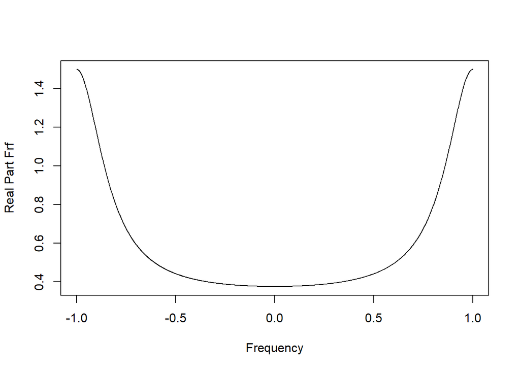

```r
lambda <- pi*seq(-1000,1000)/1000
theta1 <- .6
forecast.frf <- theta1/(1 + theta1*exp(-1i*lambda))
forecast.gain <- Mod(forecast.frf)
forecast.phase <- atan(Im(forecast.frf)/Re(forecast.frf))
forecast.delay <- -1*forecast.phase/lambda
forecast.delay[1001] <- NA
plot(ts(Re(forecast.frf),start=-1,frequency=1000),
    xlab="Frequency",ylab="Real Part Frf")
```

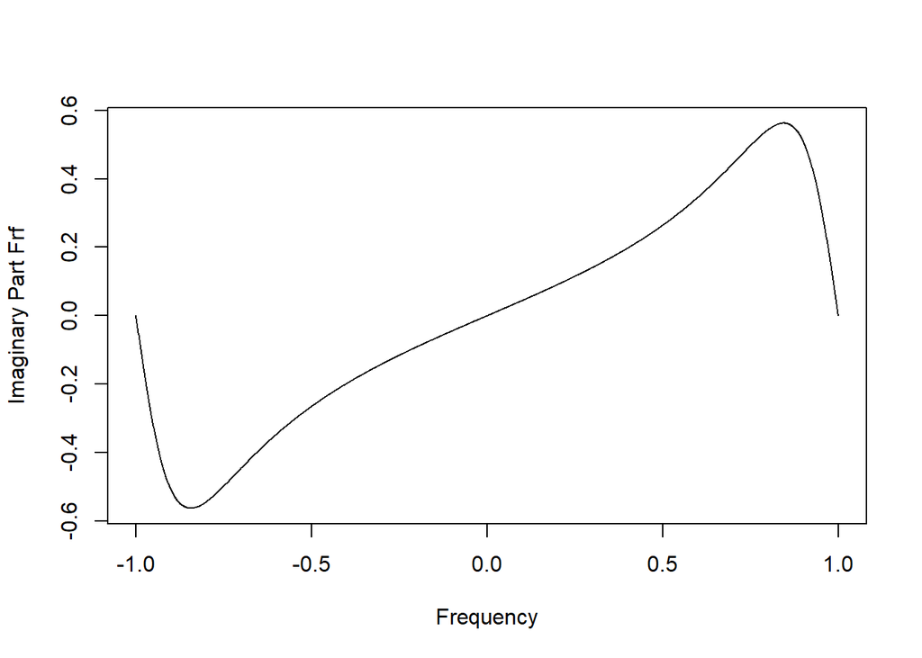

```r
plot(ts(Im(forecast.frf),start=-1,frequency=1000),
    xlab="Frequency",ylab="Imaginary Part Frf")
```

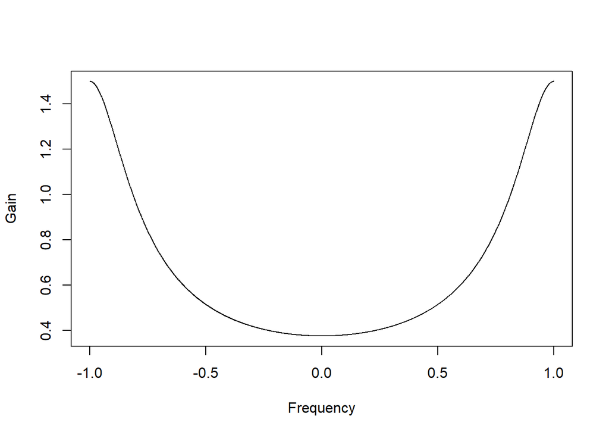

```r
plot(ts(forecast.gain,start=-1,frequency=1000),
    xlab="Frequency",ylab="Gain")
```

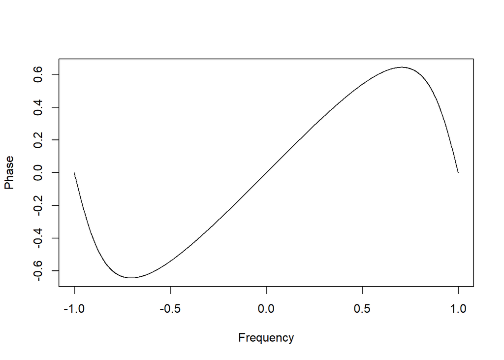

```r
plot(ts(forecast.phase,start=-1,frequency=1000),
    xlab="Frequency",ylab="Phase")
```

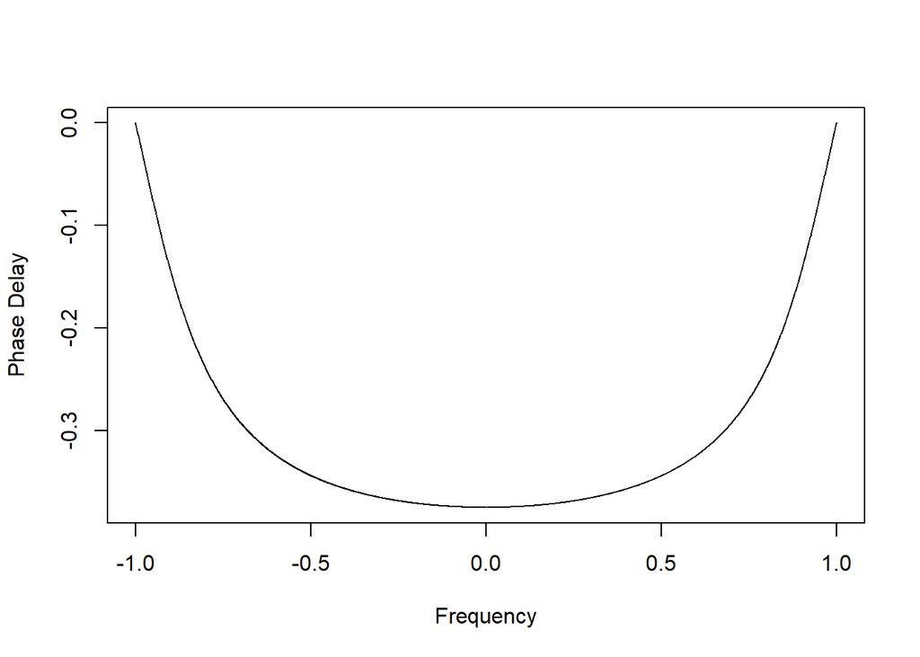

```r
plot(ts(forecast.delay,start=-1,frequency=1000),
    xlab="Frequency",ylab="Phase Delay")
```

### Example of an MA(2)

- We specialize the above result to an MA(2), where $\theta (z)= 1 + \theta_1 z + \theta_2 z^2$:
  $$\psi (e^{-i \lambda}) = \sum_{k \geq 0} \theta_{k+h} e^{-i \lambda k} /
  \theta (e^{-i \lambda})
  = 1_{ \{ h \leq 2 \} } (\theta_h + \theta_{h+1} e^{-i \lambda}) / (1 +
  \theta_1 e^{-i \lambda} + \theta_2 e^{- i 2 \lambda}).$$
- So if $h > 2$, the forecast is zero!
- Plots for the $h=1$ case:

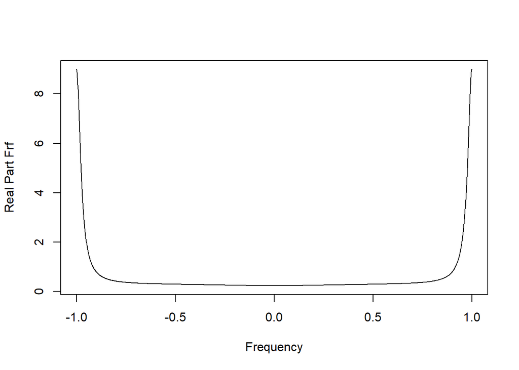

```r
lambda <- pi*seq(-1000,1000)/1000
theta1 <- .6
theta2 <- -.3
h <- 1
forecast.frf <- (theta1 + theta2*exp(-1i*lambda))/(1 + theta1*exp(-1i*lambda) + theta2*exp(-1i*2*lambda))
forecast.gain <- Mod(forecast.frf)
forecast.phase <- atan(Im(forecast.frf)/Re(forecast.frf))
forecast.delay <- -1*forecast.phase/lambda
forecast.delay[1001] <- NA
plot(ts(Re(forecast.frf),start=-1,frequency=1000),
    xlab="Frequency",ylab="Real Part Frf")
```

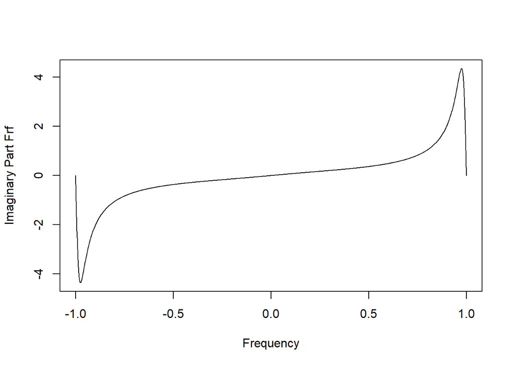

```r
plot(ts(Im(forecast.frf),start=-1,frequency=1000),
    xlab="Frequency",ylab="Imaginary Part Frf")
```

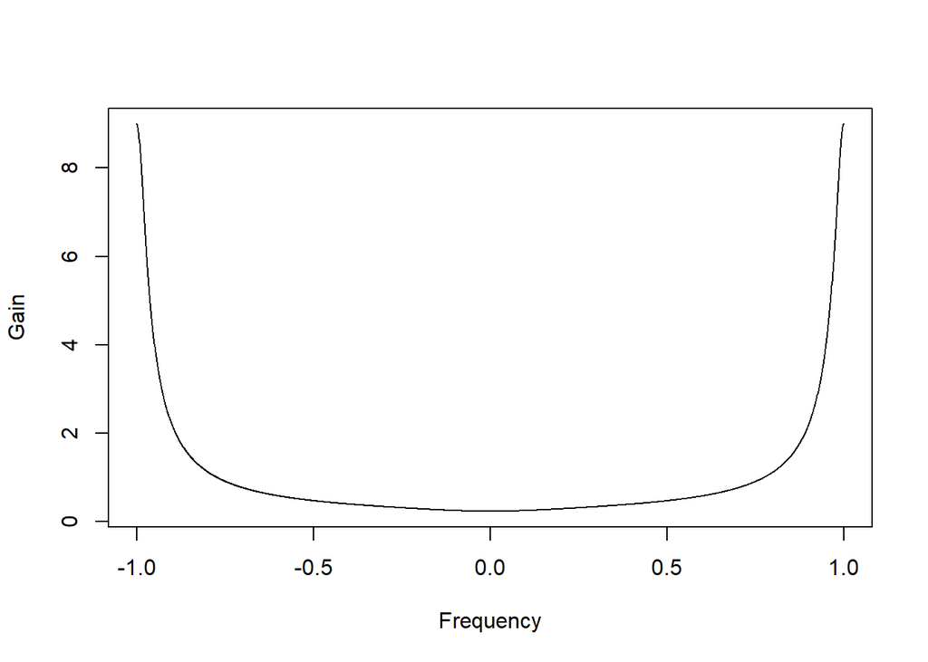

```r
plot(ts(forecast.gain,start=-1,frequency=1000),
    xlab="Frequency",ylab="Gain")
```

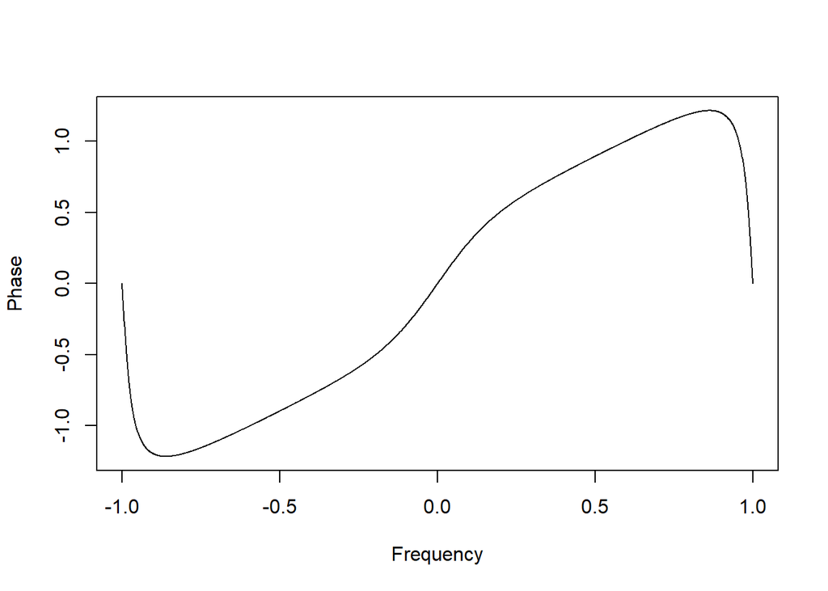

```r
plot(ts(forecast.phase,start=-1,frequency=1000),
    xlab="Frequency",ylab="Phase")
```

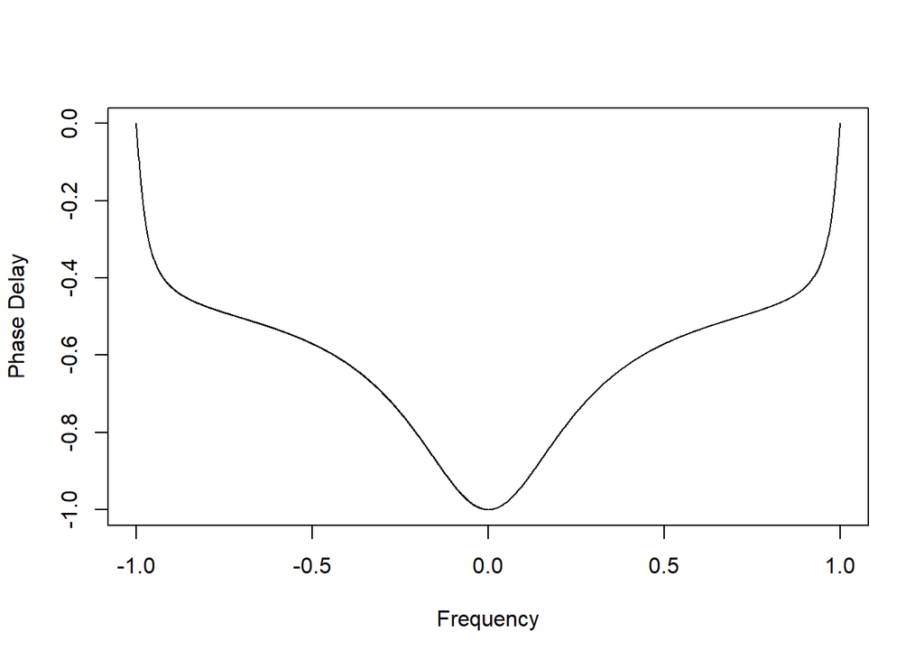

```r
plot(ts(forecast.delay,start=-1,frequency=1000),
    xlab="Frequency",ylab="Phase Delay")
```

Plots for the $h=2$ case:

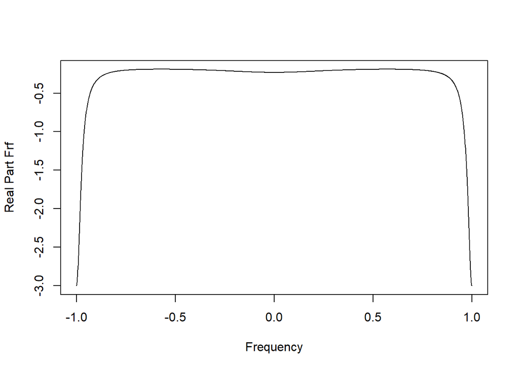

```r
lambda <- pi*seq(-1000,1000)/1000
theta1 <- .6
theta2 <- -.3
h <- 2
forecast.frf <- theta2/(1 + theta1*exp(-1i*lambda) + theta2*exp(-1i*2*lambda))
forecast.gain <- Mod(forecast.frf)
forecast.phase <- atan(Im(forecast.frf)/Re(forecast.frf))
forecast.delay <- -1*forecast.phase/lambda
forecast.delay[1001] <- NA
plot(ts(Re(forecast.frf),start=-1,frequency=1000),
    xlab="Frequency",ylab="Real Part Frf")
```

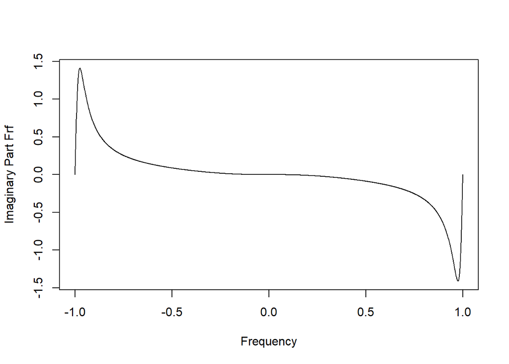

```r
plot(ts(Im(forecast.frf),start=-1,frequency=1000),
    xlab="Frequency",ylab="Imaginary Part Frf")
```

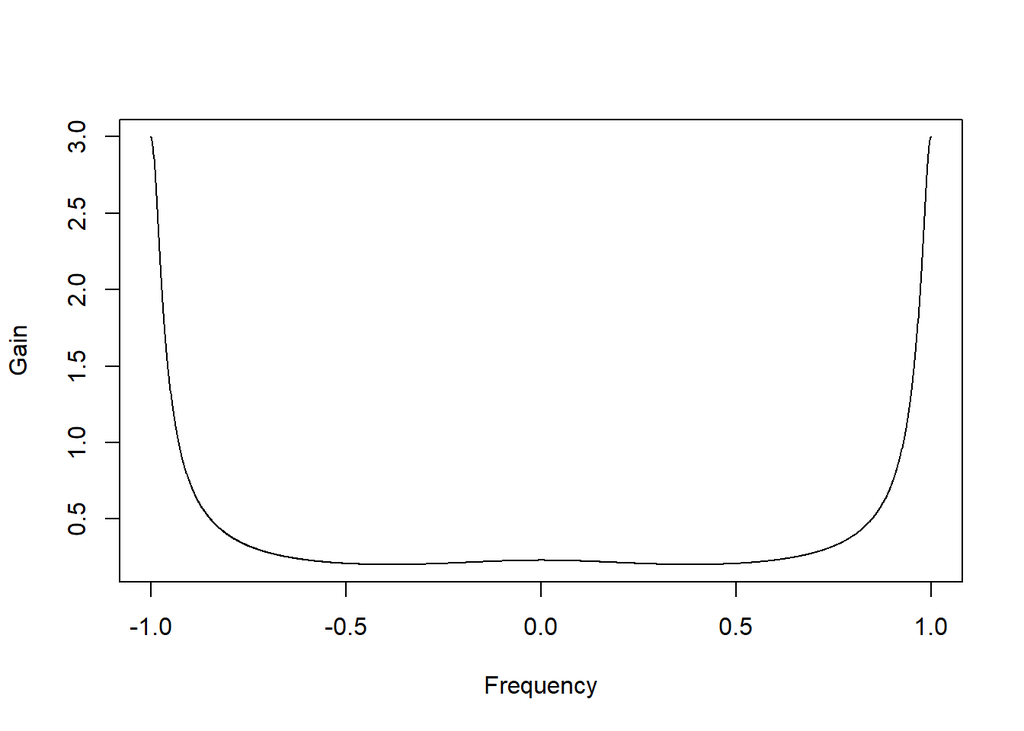

```r
plot(ts(forecast.gain,start=-1,frequency=1000),
    xlab="Frequency",ylab="Gain")
```

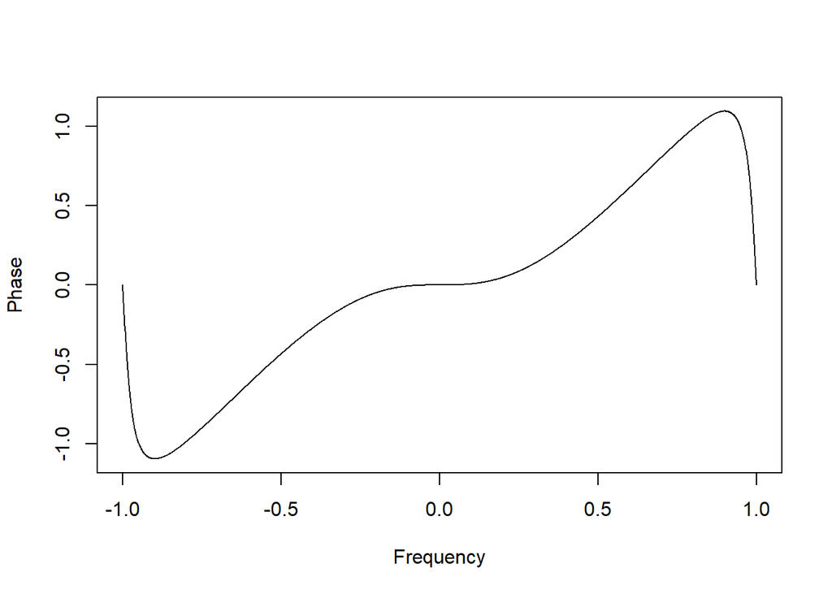

```r
plot(ts(forecast.phase,start=-1,frequency=1000),
    xlab="Frequency",ylab="Phase")
```

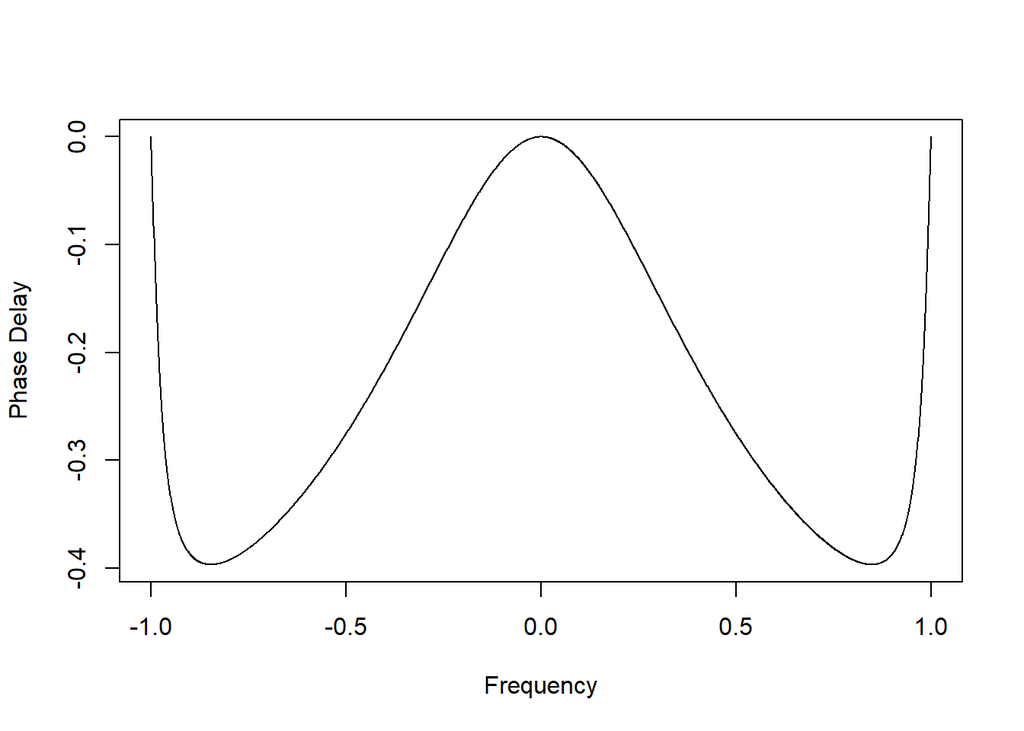

```r
plot(ts(forecast.delay,start=-1,frequency=1000),
    xlab="Frequency",ylab="Phase Delay")
```